# Analyzing Trends in Summer Olympic Games Medals

Gabriela Diaz, Felicia Peterson, & Gabby Valle

4/12/2022

```r
#knitr::opts_chunk$set(echo = TRUE, error=TRUE, message=FALSE, warning=FALSE)
```

```r
library(tidyverse)     # for data cleaning and plotting
library(lubridate)     # for date manipulation
library(openintro)     # for the abbr2state() function
library(maps)          # for map data
library(ggmap)         # for mapping points on maps
library(gplots)        # for col2hex() function
library(RColorBrewer)  # for color palettes
library(sf)            # for working with spatial data
library(leaflet)       # for highly customizable mapping
library(ggthemes)
library(plotly)        # for the ggplotly() - basic interactivity
library(gganimate)     # for adding animation layers to ggplots
library(gifski)        # for creating the gif (don't need to load this library every time,but need it installed)
library(transformr)    # for "tweening" (gganimate)
library(shiny)         # for creating interactive apps
library(patchwork)     # for nicely combining ggplot2 graphs
library(gt)            # for creating nice tables
library(countrycode)
theme_set(theme_minimal())
```

Every four years (or two), the world holds its breath as individual humans represent whole countries through their mastery of a sport. We data scientists have analyzed the Summer Olympics from the year 1896 to 2016–yes, 120 years of the top athletes competing for the glory, and, perhaps more importantly, the gold.

**You should also eliminate the code by adding echo=FALSE** to the options. You may want to wait until after your analysis is complete to include that section because you don’t want to miss those while you’re working on your analysis.

## Original Data

This data hails from Kaggle from the games in Athens 1896 to Rio 2016; more recently, it was popularized through the weekly R challenge “Tidy Tuesday.” Until 1992, the Winter and Summer Games coincided in the same year, which results in odd data points like a Figure Skating victory slipping into the Summer Olympics data sets. Other aspects of the history of the Olympics include the existence and end to whole nations as the years progress. Examples include East and West Germany and the Soviet Union–as well as unrecognized independent territories such as Kosovo and Taiwan. Our team’s methodology to eliminate our own biases was to keep the data points that reflect 2016’s Olympic Games for sports measured and the countries recognized are universally agreed upon by the international community.

```r
olympics <- readr::read_csv('https://raw.githubusercontent.com/rfordatascience/tidytuesday/master/data/2021/2021-07-27/olympics.csv')
```

```r
world <- map_data("world")

medal_colors <- c(
  Gold = "#d5a500",
  Silver = "#b7b7b7",
  Bronze = "#a17419")
```

Filtered Data Sets

```r
summer_olympics <- olympics %>%
  filter(season == "Summer") %>%
   mutate(countryName = countrycode(noc, "genc3c", "country.name")) %>%
   mutate(countryName = ifelse(countryName == "United States", "USA", countryName)) %>%
   mutate(countryName = ifelse(noc == "ALG", "Algeria", countryName)) %>%
   mutate(countryName = ifelse(noc == "BAH", "Bahamas", countryName)) %>%
   mutate(countryName = ifelse(noc == "BUL", "Bulgaria", countryName)) %>%
   mutate(countryName = ifelse(noc == "CHI", "Chile", countryName)) %>%
   mutate(countryName = ifelse(noc == "CRC", "Costa Rica", countryName)) %>%
   mutate(countryName = ifelse(noc == "CRO", "Croatia", countryName)) %>%
   mutate(countryName = ifelse(noc == "CZA", "Czech Republic", countryName)) %>%
   mutate(countryName = ifelse(noc == "DEN", "Denmark", countryName)) %>%
   mutate(countryName = ifelse(noc == "FIJ", "Fiji", countryName)) %>%
   mutate(countryName = ifelse(noc == "GER", "Germany", countryName)) %>%
   mutate(countryName = ifelse(noc == "GRE", "Greece", countryName)) %>%
   mutate(countryName = ifelse(noc == "GRN", "Grenada", countryName)) %>%
   mutate(countryName = ifelse(noc == "HAI", "Haiti", countryName)) %>%
   mutate(countryName = ifelse(noc == "INA", "Indonesia", countryName)) %>%
   mutate(countryName = ifelse(noc == "IRI", "Iran", countryName)) %>%
   mutate(countryName = ifelse(noc == "LAT", "Latvia", countryName)) %>%
   mutate(countryName = ifelse(noc == "MGL", "Mongolia", countryName)) %>%
   mutate(countryName = ifelse(noc == "NED", "Netherlands", countryName)) %>%
   mutate(countryName = ifelse(noc == "NGR", "Nigeria", countryName)) %>%
   mutate(countryName = ifelse(noc == "POR", "Portugal", countryName)) %>%
   mutate(countryName = ifelse(noc == "PUR", "Puerto Rico", countryName)) %>%
   mutate(countryName = ifelse(noc == "RSA", "South Africa", countryName)) %>%
   mutate(countryName = ifelse(noc == "SLO", "Slovenia", countryName)) %>%
   mutate(countryName = ifelse(noc == "SUI", "Switzerland", countryName)) %>%
   mutate(countryName = ifelse(noc == "UAE", "United Arab Emirates", countryName)) %>%
   mutate(countryName = ifelse(noc == "URU", "Uruguay", countryName)) %>%
   mutate(countryName = ifelse(noc == "VIE", "Vietnam", countryName)) %>%
   mutate(countryName = ifelse(noc == "ZIM", "Zimbabwe", countryName))
# Footnote or mention in part of the project the choice to leave out territories not fully recognized, such as Kosovo and Chinese Taipei, and countries that no longer exist, including the Soviet Union and Yugoslavia.


summer_gold <- summer_olympics %>%
  drop_na(medal) %>%
  filter(medal == "Gold")

summer_medals <- summer_olympics %>%
  drop_na(medal)

medal_prop <- summer_olympics %>%
  count(countryName, medal) %>%
  group_by(countryName) %>%
  filter(any(!is.na(medal))) %>%
  mutate(medal = ifelse(is.na(medal), "No Medal", medal)) %>%
  pivot_wider(
    names_from = medal,
    values_from = n,
    values_fill = 0) %>%
  mutate(
    total_medals = Gold + Silver + Bronze,
    total_events = total_medals + `No Medal`,
    p_medal = total_medals / total_events) %>%
  arrange(desc(total_medals))
```

Female-only, medal-winning data:

```r
golden_girls <- summer_gold %>%
  filter(sex == "F") %>%
  drop_na(height, weight)
```

Instructions that might be useful to remember:

- **NEW!!** With animated graphs, add `eval=FALSE` to the code chunk that creates the animation and saves it using `anim_save()`. Add another code chunk to reread the gif back into the file. See the [tutorial](https://animation-and-interactivity-in-r.netlify.app/) for help.
- When you are finished with ALL the exercises, uncomment the options at the top so your document looks nicer. Don’t do it before then, or else you might miss some important warnings and messages.

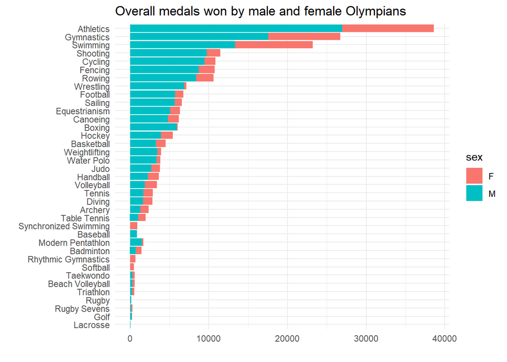

```r
summer_olympics %>%
  group_by(sex, sport) %>%
  count(medal) %>%
  filter(!(sport %in% c("Aeronautics", "Art Competitions", "Jeu De Paume", "Roque", "Alpinism", "Basque Pelota", "Croquet", "Racquets", "Figure Skating", "Ice Hockey", "Cricket", "Polo", "Trampolining", "Tug-Of-War", "Motorboating"))) %>%
  ggplot(aes(x = n, y = reorder(sport, n), fill = sex)) +
  geom_col() +
  labs(y = "",
        title = "Overall medals won by male and female Olympians",
       x = "")
```

## **2. Olympic medal winning women’s heights and weights**

```r
#weight in kg
# Athletics = track and field
# Hockey = Field Hockey
#Leaving out figure skating because  1920s Olympics, one gold winner

golden_girls <- summer_medals %>%
  filter(sex == "F") %>%
  drop_na(height, weight)
golden_girls
```

```
## # A tibble: 8,665 x 16
##       id name    sex     age height weight team   noc   games  year season city
##    <dbl> <chr>   <chr> <dbl>  <dbl>  <dbl> <chr>  <chr> <chr> <dbl> <chr>  <chr>
##  1    37 Ann Kr~ F        23    182     64 Norway NOR   1996~  1996 Summer Atla~
##  2    65 Patima~ F        21    165     49 Azerb~ AZE   2016~  2016 Summer Rio ~
##  3    67 Mariya~ F        22    179     80 Russia RUS   2008~  2008 Summer Beij~
##  4    90 Tamila~ F        21    163     60 Russia RUS   2004~  2004 Summer Athi~
##  5   153 Monica~ F        23    191     88 Unite~ USA   2008~  2008 Summer Beij~
##  6   165 Nia Ni~ F        20    175     56 Unite~ USA   2004~  2004 Summer Athi~
##  7   259 Reema ~ F        21    173     59 Canada CAN   1984~  1984 Summer Los ~
##  8   394 Irene ~ F        19    160     48 East ~ GDR   1972~  1972 Summer Muni~
##  9   395 Jennif~ F        20    160     62 Canada CAN   2012~  2012 Summer Lond~
## 10   428 Elvan ~ F        25    159     40 Turkey TUR   2008~  2008 Summer Beij~
## # ... with 8,655 more rows, and 4 more variables: sport <chr>, event <chr>,
## #   medal <chr>, countryName <chr>
```

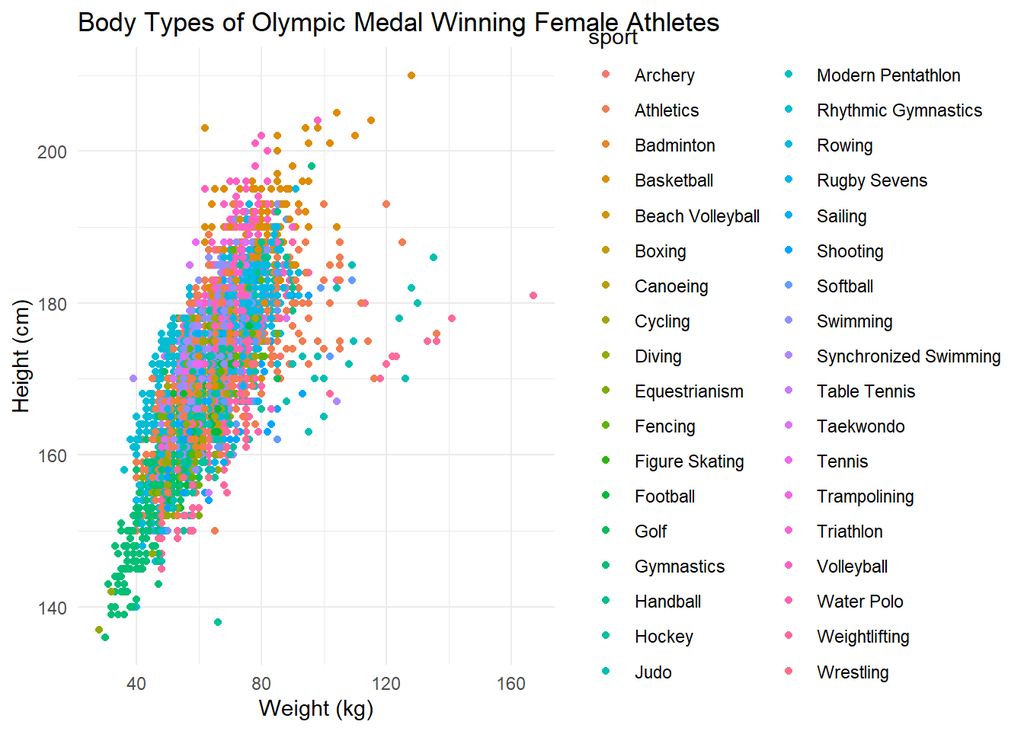

```r
golden_girls %>%
  ggplot(aes(x = weight, y = height, color = sport)) +
  geom_point() +
  labs(title = "Body Types of Olympic Medal Winning Female Athletes",
    y = "Height (cm)",
       x = "Weight (kg)")
```

Above is a graph that shows all the female athletes in one graph, showing a wide range of heights and weights of Olympians. However, due to the amount of sports, the graph itself is very noisy. To better understand the trends, the same data is compiled into four different categories.

The first category is “Holding an object”: These athletes are holding onto something, whether it is the reigns of a horse or a racket, they are armed.

The second is “Wearing protective gear.” The athletes in this category are wearing an extra layer designed for their sport to reduce injury.

The third is “In water.” As it sounds, these athletes are found in the water to compete.

Lastly, there is “Just self.” These athletes are not holding anything, wearing something meant to protect them, or are in the water.

```r
equip_gg <- golden_girls %>%
  filter(sport == c("Badminton", "Cycling", "Equestrianism", "Golf",  "Hockey", "Shooting", "Softball", "Table Tennis", "Tennis", "Rhythmic Gymnastics", "Weightlifting"))
equip_gg
```

```
## # A tibble: 133 x 16
##       id name    sex     age height weight team   noc   games  year season city
##    <dbl> <chr>   <chr> <dbl>  <dbl>  <dbl> <chr>  <chr> <chr> <dbl> <chr>  <chr>
##  1  1169 "Maril~ F        33    172     58 Nethe~ NED   2012~  2012 Summer Lond~
##  2  1546 "Eirin~ F        17    167     45 Greece GRE   2000~  2000 Summer Sydn~
##  3  4418 "Alyso~ F        27    162     65 Austr~ AUS   2000~  2000 Summer Sydn~
##  4  6624 "Diana~ F        33    175     85 Italy  ITA   2016~  2016 Summer Rio ~
##  5 11448 "Fiona~ F        40    173     75 Great~ GBR   2016~  2016 Summer Rio ~
##  6 12113 "Elisa~ F        16    168     49 Italy  ITA   2004~  2004 Summer Athi~
##  7 14578 "Jeane~ F        26    169     60 Great~ GBR   2000~  2000 Summer Sydn~
##  8 15540 "Joann~ F        28    174     72 Austr~ AUS   2000~  2000 Summer Sydn~
##  9 17479 "Els C~ F        30    177     58 Belgi~ BEL   2000~  2000 Summer Sydn~
## 10 22054 "Mario~ F        32    170     60 France FRA   1996~  1996 Summer Atla~
## # ... with 123 more rows, and 4 more variables: sport <chr>, event <chr>,
## #   medal <chr>, countryName <chr>
```

```r
armor_gg <- golden_girls %>%
  filter(sport == c("Boxing", "Judo", "Fencing", "Football", "Taekwondo", "Rugby Sevens"))
armor_gg
```

```
## # A tibble: 152 x 16
##       id name    sex     age height weight team   noc   games  year season city
##    <dbl> <chr>   <chr> <dbl>  <dbl>  <dbl> <chr>  <chr> <chr> <dbl> <chr>  <chr>
##  1  1191 "Judit~ F        27    164     62 Hunga~ HUN   1964~  1964 Summer Tokyo
##  2  1730 "Monic~ F        26    183     74 Unite~ USA   2016~  2016 Summer Rio ~
##  3  2769 "Kimia~ F        18    185     57 Iran   IRI   2016~  2016 Summer Rio ~
##  4  3593 "An Ku~ F        28    160     52 North~ PRK   2008~  2008 Summer Beij~
##  5  4101 "Andri~ F        26    175     65 Brazil BRA   2004~  2004 Summer Athi~
##  6  5631 "Kosov~ F        27    166     56 Sweden SWE   2016~  2016 Summer Rio ~
##  7  7597 "Bao Y~ F        24    172     67 China  CHN   2008~  2008 Summer Beij~
##  8  7717 "Brbar~ F        20    171     71 Brazil BRA   2008~  2008 Summer Beij~
##  9  7920 "Valri~ F        27    165     53 France FRA   1996~  1996 Summer Atla~
## 10  8364 "Saski~ F        33    170     60 Germa~ GER   2016~  2016 Summer Rio ~
## # ... with 142 more rows, and 4 more variables: sport <chr>, event <chr>,
## #   medal <chr>, countryName <chr>
```

```r
hydro_gg <- golden_girls %>%
  filter(sport == c("Canoeing", "Diving", "Water Polo", "Rowing", "Swimming", "Synchronized Swimming", "Sailing"))
hydro_gg
```

```
## # A tibble: 406 x 16
##       id name    sex     age height weight team   noc   games  year season city
##    <dbl> <chr>   <chr> <dbl>  <dbl>  <dbl> <chr>  <chr> <chr> <dbl> <chr>  <chr>
##  1   395 "Jenni~ F        20    160     62 Canada CAN   2012~  2012 Summer Lond~
##  2   980 "Rebec~ F        23    179     70 Great~ GBR   2012~  2012 Summer Lond~
##  3  1380 "Chris~ F        22    172     52 Unite~ USA   1992~  1992 Summer Barc~
##  4  2443 "Joan ~ F        17    170     59 Unite~ USA   1952~  1952 Summer Hels~
##  5  2464 "Jo Qe~ F        30    171     58 New Z~ NZL   2016~  2016 Summer Rio ~
##  6  2575 "Lisa ~ F        27    172     58 Canada CAN   1996~  1996 Summer Atla~
##  7  3070 "Malin~ F        23    180     64 Sweden SWE   2000~  2000 Summer Sydn~
##  8  3880 "Agnet~ F        31    172     68 Sweden SWE   1992~  1992 Summer Barc~
##  9  4393 "Herta~ F        26    183     82 Roman~ ROU   1988~  1988 Summer Seoul
## 10  4720 "Tessa~ F        27    177     71 Nethe~ NED   2000~  2000 Summer Sydn~
## # ... with 396 more rows, and 4 more variables: sport <chr>, event <chr>,
## #   medal <chr>, countryName <chr>
```

```r
solo_gg <- golden_girls %>%
  filter(sport == c("Athletics", "Basketball", "Beach Volleyball", "Gymnastics", "Handball", "Trampolining", "Triathalon", "Volleyball", "Wrestling" ))
solo_gg
```

```
## # A tibble: 353 x 16
##       id name     sex     age height weight team  noc   games  year season city
##    <dbl> <chr>    <chr> <dbl>  <dbl>  <dbl> <chr> <chr> <chr> <dbl> <chr>  <chr>
##  1   428 Elvan A~ F        25    159     40 Turk~ TUR   2008~  2008 Summer Beij~
##  2   610 Ginko A~ F        26    148     46 Japan JPN   1964~  1964 Summer Tokyo
##  3  1020 Adriana~ F        29    180     61 Braz~ BRA   2000~  2000 Summer Sydn~
##  4  1071 Kseniya~ F        20    158     48 Russ~ RUS   2012~  2012 Summer Lond~
##  5  1254 Macaren~ F        27    170     67 Spain ESP   2012~  2012 Summer Lond~
##  6  1313 Robyn M~ F        32    172     67 Unit~ USA   2008~  2008 Summer Beij~
##  7  1564 Chioma ~ F        24    164     57 Nige~ NGR   1996~  1996 Summer Atla~
##  8  1732 Liudmyl~ F        29    165     58 Sovi~ URS   1976~  1976 Summer Mont~
##  9  2546 Alessan~ F        22    200     85 Braz~ BRA   1996~  1996 Summer Atla~
## 10  3281 Simona ~ F        16    158     44 Roma~ ROU   1996~  1996 Summer Atla~
## # ... with 343 more rows, and 4 more variables: sport <chr>, event <chr>,
## #   medal <chr>, countryName <chr>
```

[figure not shown]

```r
fig1 <- equip_gg %>%
  ggplot(aes(x = weight, y = height, color = sport)) +
  geom_point() +
  theme(legend.title = element_blank(),
        legend.text = element_text(size = 7)) +
  labs(x = "",
       y = "")

fig2 <- armor_gg %>%
  ggplot(aes(x = weight, y = height, color = sport)) +
  geom_point() +
  theme(legend.title = element_blank(),
        legend.text = element_text(size = 7)) +
  labs(x = "",
       y = "")


fig3 <- hydro_gg %>%
  ggplot(aes(x = weight, y = height, color = sport)) +
  geom_point() +
  theme(legend.title = element_blank(),
        legend.text = element_text(size = 7)) +
   labs(x = "Weight (cm)",
       y = "Height (kg)")

fig4 <- solo_gg %>%
  ggplot(aes(x = weight, y = height, color = sport),
         legend.text = element_text(size = 7)) +
  geom_point() +
  theme(legend.title = element_blank(),
        legend.text = element_text(size = 7)) +
  labs(x = "Height (cm)",
       y = "Weight (kg)")


fig1 + fig2 + fig3 + fig4 +
  plot_annotation(title = "Olympic Medal Winning Women",
                  subtitle = "Trends in height and weight for female athletes depending on sport")
```

## **3. World map showing the proportion of Olympic medal wins to participation in events**

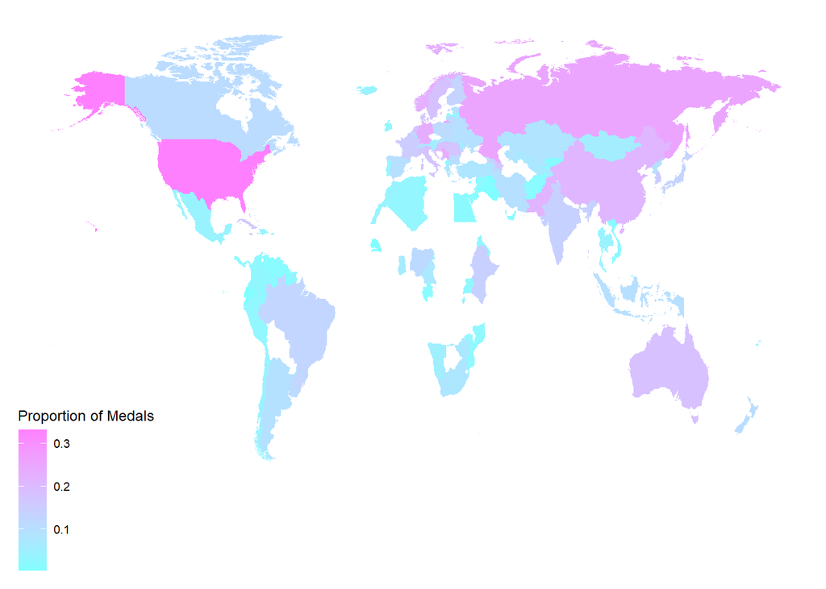

```r
medal_prop %>%
  mutate(countryName = ifelse(countryName == "United States", "USA", countryName)) %>%
  ggplot() +
  geom_map(map = world,
           aes(map_id = countryName,
               fill = p_medal)) +
  scale_fill_gradient(low=cm.colors(20)[1], high=cm.colors(20)[20])+
  #scale_colour_manual(values = countryName, na.value = "#34521") +
  expand_limits(x = world$long, y = world$lat) +
  theme_map() +
  labs(fill = "Proportion of Medals") +
  theme(legend.key = element_rect(fill = "transparent"))
```